# Explanatory Analysis

Allison Li, Tim Chen, Daniel Chen, Kevin Ryu

2/15/2021

### Introduction

The data was gathered from the COVID Tracking Project and Boston University Center for Antiracist Research. They obtained the data from the states reports of them. This dataset helps to answer our research question in looking at a lot of different variables regarding how COVID-19 has affected different ethnicities across the U.S. In looking at these variables and doing analysis over them some important findings can be made about the ways in which different ethnicities in the U.S. dealt with COVID-19.

### Summary

The information that we had summarized is the main columns that were apparent in the dataset.These values give the readers a good context around the gravity and impact of COVID 19 on the nation.These values were total cases, deaths, hospitalizations, and tests by race as well as the number of observations or rows in our dataset. From the most recent data, we found that there were 27328918 total cases in the nation, 76345974 total tests done, 484669 total deaths, and 539535 total hospitalizations. We also calculated that there were4984 total data points in our dataset.

### Aggregate Table

The table depicts the total cases, deaths, hospitalizations, tests, and the proportion of deaths over hospitalizations for each ethnic group in the United States as of present date. Because our data did not include a column with ethnicities but had values for each specific ethnicity as a column (for example, cases_white, cases_black, etc.), the table was created by isolating each different category into their own data frames. Once isolated and grouped into ethnicities within the same category, we were able to join together the different data frames into one to create a data frame that grouped each category (cases, deaths, hospitalizations, tests, and the proportion of deaths over hospitalizations) by ethnicities without explicitly using the group_by function.

| Ethnicity | Cases | Deaths | Hospitalizations | Tests | Prop_Deaths_Hopsitalizations |
| --- | --- | --- | --- | --- | --- |
| White | 9978336 | 269732 | 249309 | 20523623 | 1.0819184 |
| Black | 2273683 | 67925 | 83092 | 3638325 | 0.8174674 |
| Latinx | 3535946 | 76356 | 102647 | 12499664 | 0.7438698 |
| Asian | 532467 | 15348 | 18085 | 4446314 | 0.8486591 |
| AIAN | 215470 | 4365 | 12033 | 162426 | 0.3627524 |
| NHPI | 52219 | 785 | 2089 | 240764 | 0.3757779 |
| Multiracial | 152604 | 2017 | 2934 | 75084 | 0.6874574 |
| Other | 1502985 | 15229 | 19778 | 8849527 | 0.7699970 |
| Unknown | 9117661 | 33067 | 50632 | 25999015 | 0.6530850 |
| Hispanic | 4212922 | 81830 | 109328 | 12782035 | 0.7484816 |
| NonHispanic | 11886188 | 351405 | 366102 | 34749441 | 0.9598555 |
| Ethnicity_Unknown | 11135554 | 49513 | 58359 | 28814498 | 0.8484210 |

### Chart 1

We decided to focus on specifically Asian cases because we personally related to this demographic the most as an entirely Asian group. Especially in the current climate of sinophobia in the nation, we wanted to see if the actual data warrants the fear against Asians specifically. This chart presents a clear picture of how Asian cases were distributed amongst the U.S. states and territories in the dataset from April 2020 to February 2021. Some important observations from this chart were that a lot of the distribution tended to be seen in the front of the chart meaning that there Asian cases tended to be mostly between 0 and 50,000.

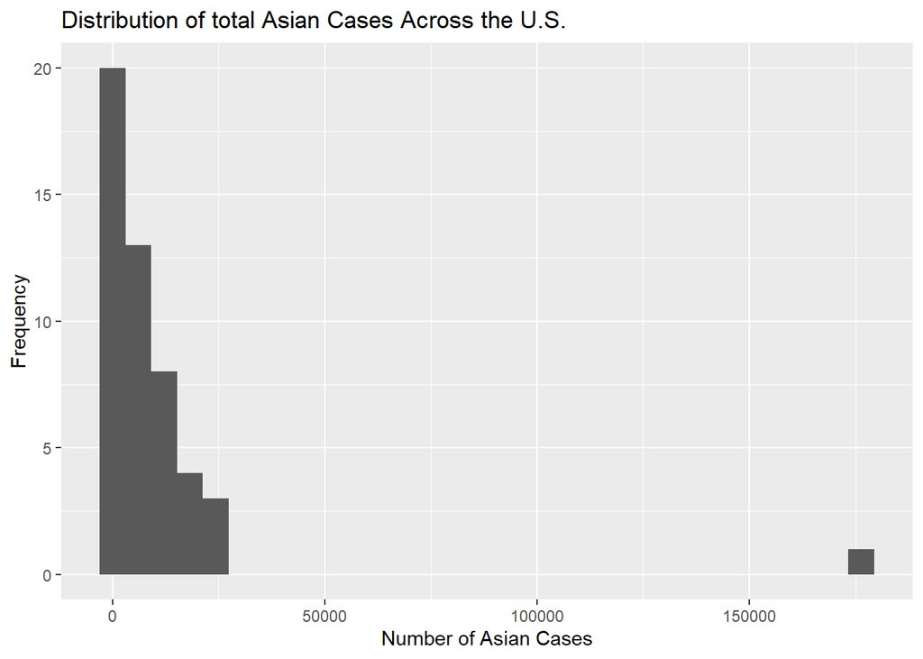

### Chart 2

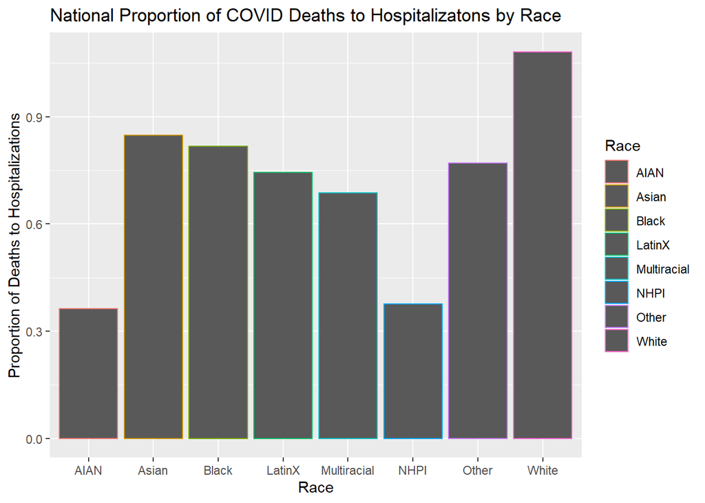

### Chart 3

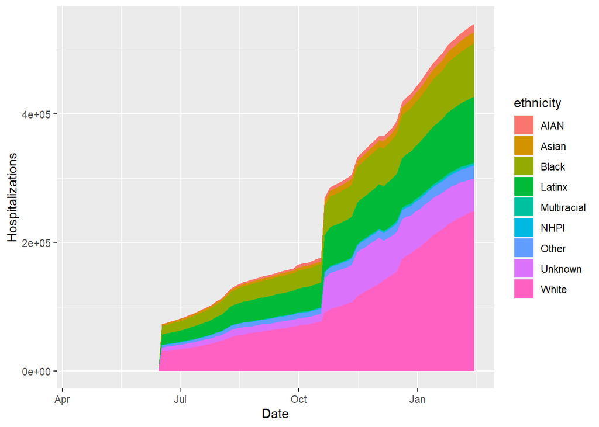